# Pitch of the capstone project

2023-05-25

## Basic idea of the app

This app can be used for prediction of the next word after a user defined phrase.

You type in a phrase

→ the app predicts the next word

→ how great is that?

Basis for this prediction is the data provided on this website https://d396qusza40orc.cloudfront.net/dsscapstone/dataset/Coursera-SwiftKey.zip

## Structure of the app

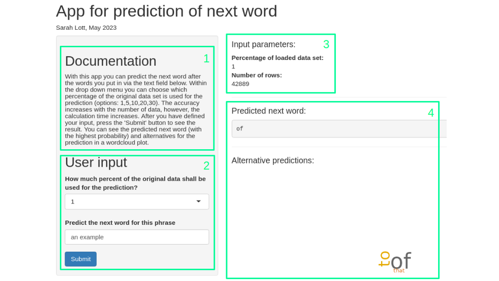

| Section | Description |
| --- | --- |
| 1 | Description of the app |
| 2 | User input - choose the data set and the type in your phrase |
| 3 | Display of the input parameters |
| 4 | Display of the prediction |

## Descripton of the algorithm

The data used for the prediction in the app is a randomly selected partial data set.

For the natural language processing the R-package quanteda is used.

- Step 1: preprocessing of the user input (convert to lower case, remove leading and/or trailing whitespace, count number of words for the n-gram algorithm)
- Step 2: filter the data set according to the user input → only the filtered lines are considered in the following, this saves computational effort
- Step 3: construct a tokens object
- Step 4: create a set of n-grams (tokens in sequence) from the tokenized text object
- Step 5: use kwic() function to find the indexes of the token positions for the input phrase
- Step 6: extract the subsequent words of the input phrase from the kwic data frame
- Step 7: analyse the frequency of the subsequent words

## Advantages of the app

- user input is automatically preprocessed
- input of different phrase lengths possible
- the user can balance accuracy and speed himself
- alternative predictions are displayed additionally

→ Outstanding user friendliness

[figure not shown]

- the code is written in such a universal way that it can be easily adapted for other languages

→ Easily expandable

[figure not shown]